# Usa y Arg 2019

# Introducción

Como primer ejercicio tomé las bases de 2019 de USA (Marzo) y ARG (1er trim) para hacer la comparación entre los grupos propuestos. Son las que tenía más a mano, una vez que definamos un poco más como seguir lo estiro para el resto de los años. Además me parece bueno hacer la comparación puntual entre países en un momento del tiempo y luego extenderlo.  
Dado que la compatibilidad entre clasificadores de ocupación no es tán directa, la variable ligada a la subjetividad productiva de los trabajadores será el nivel educativo. Igualmente para argentina muestro unos datos de calificaciones.

```
Use of data from IPUMS-CPS is subject to conditions including that users should
cite the data appropriately. Use command `ipums_conditions()` for more details.
```

# Clasificacion

- USA:
  - Tamaños de empresa: 1 a 9, 10 a 49, más de 50. (La pregunta está hecha a nivel empresa, no establecimiento)
  - Nivel educativo: Menor a secundaria, secundaria, terciario o más
  - Filtros: Ocupados privados sin servicio doméstico (filtrado por rama)
- Argentina:
  - Tamaños de empresa: 1 a 10, 11 a 40, más de 40. (Recuperos asignados al grupo más cercano)
  - Nivel educativo: Menor a secundaria, secundaria, terciario o más
  - Filtros: Ocupados privados sin servicio doméstico (filtrado por rama)

[output not shown]

# Inserción s/ niveles educativos

Antes de analizar los perfiles para cada uno de los grupos, tiro un par de daos sobre la composición de la PEA y de los ocupados en función de los niveles educativos, así como las tasas de desempleo en cada uno de los grupos.

## Argentina

| ANO4 | grupos.nivel.ed | tasa.desocup | PEA.porc | ocup.porc |
| --- | --- | --- | --- | --- |
| 2019 | Menor a Secundaria | 0.11915867 | 0.3454405 | 0.3383578 |
| 2019 | Secundaria Completa | 0.11627626 | 0.4298042 | 0.4223694 |
| 2019 | Superior Completo | 0.04263338 | 0.2247552 | 0.2392728 |

## USA

| YEAR | grupos.nivel.ed | tasa.desocup | PEA.porc | ocup.porc |
| --- | --- | --- | --- | --- |
| 2019 | Menor a Secundaria | 0.08874811 | 0.0855565 | 0.08109924 |
| 2019 | Secundaria Completa | 0.04338436 | 0.5344579 | 0.53183432 |
| 2019 | Superior Completo | 0.02075115 | 0.3799856 | 0.38706644 |

## Lectura

2 datos importantes: En USA la PEA con menos que secundaria es muy pequeña. La desocupación crece parejo a menor nivel educativo, mientras que en argentina hay una diferencia muy notoria entre el que tiene educación superior completa y el resto.

# Tamaños empresas

Más allá de la diferencia en la clasificación de tamaños de establecimientos, acá se puede ver la diferencia en la cantidad de personas que se ocupan en empresas de distintos tamaños entre ambos países. Argentina, el 57% del empleo es en pequeñas, en USA, más del 66% en grandes

| grupos.tamanio | Pais | casos | casos.pond | peso.en.pais |
| --- | --- | --- | --- | --- |
| Pequeño | ARG | 10733 | 5223060 | 0.5699677 |
| Mediano | ARG | 3308 | 1585149 | 0.1729798 |
| Grande | ARG | 4360 | 2355573 | 0.2570525 |
| Pequeño | USA | 14968 | 27139480 | 0.1875539 |
| Mediano | USA | 11721 | 21617600 | 0.1493936 |
| Grande | USA | 51064 | 95945191 | 0.6630524 |

# 9 grupos

## Participación en el empleo total

| grupos.tamanio | grupos.nivel.ed | Participacion en el empleo ARG | Participacion en el empleo USA |
| --- | --- | --- | --- |
| Pequeño | Menor a Secundaria | 23,0 | 2,1 |
| Pequeño | Secundaria Completa | 23,7 | 10,3 |
| Pequeño | Superior Completo | 10,3 | 6,4 |
| Mediano | Menor a Secundaria | 4,9 | 1,7 |
| Mediano | Secundaria Completa | 7,8 | 8,7 |
| Mediano | Superior Completo | 4,6 | 4,6 |
| Grande | Menor a Secundaria | 4,9 | 4,1 |
| Grande | Secundaria Completa | 10,6 | 34,4 |
| Grande | Superior Completo | 10,2 | 27,8 |

## Escalera Salarial

### Niveles educativos y tamaños

El gráfico que se muestra acá no tiene la transformación de los salarios a PPP, por eso las comparaciones que se pueden hacer son a nivel nacional. No obstante se pueden comparar el nivel de las penalidades en uno y otro país. Más allá del valor absoluto puse una referencia al % que representa cada dato respecto al salario promedio en las empresas grandes p/ un mismo nivel educativo

El primero es para el total del empleo, el segundo es solo para asalariados

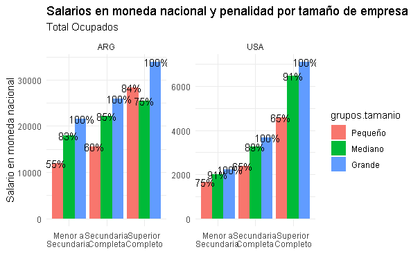

Para mi en argentina este gráfico tiene el problema de que aparecen los profesionales cuentapropistas de establecimientos chicos y tiran muy para arriba el salario. En el siguiente (solo de asalariados) se ve un poco más claro el argumento que se busca plantear

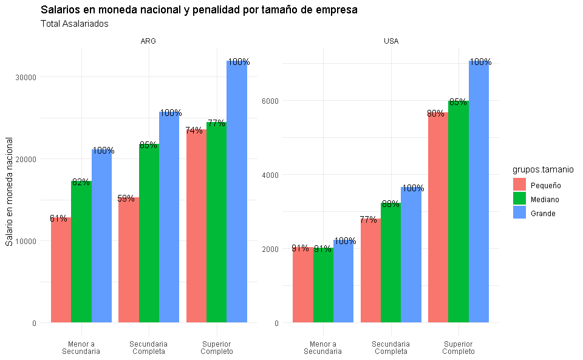

Es interesante ver que en USA lo que estratifica principalmente es el nivel de formación, y luego ahí hay una diferencia entre empresas. En Argentina ese efecto no es tan claro (en el sentido de que una persona con sec completa en empresa grande gana en promedio más que uno con sup. completa en peq y mediana). Además en todos los niveles educativos el “castigo” por emplearte en un capital pequeño es mayor en Argentina que en USA.

### Calificaciones y tamaños

En cuanto a calificaciones por ahora solo pude ver lo de argentina, dado que el clasificador del a CPS no permite delimitar ocupaciones según calificación fácilmente. Estuve investigando y habría que hacer dos *crosswalks*, uno para transformar las ocupaciones a los códigos del SOC (Clasif. utilizado en censos de USA) y otro para transformarlas a ISCO (Europa)

Lo que se puede ver para los datos de argentina es que el corte por calificación p/ asalariados da una escalerita muy similar a la de los niveles educativos propuestos.

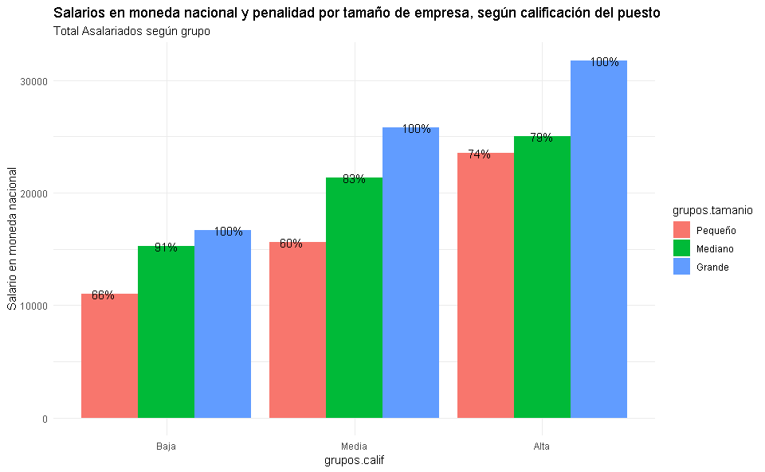

## Precariedad

En cuanto a calidad del vínculo en USA no hay información como la que buscabamos en esta encuesta (raro). De las 3 alternativas que propusimos solo se puede construir la de full o part time, y hay asociada una pregunta de porqué en caso de part time. No me metí a construir eso x ahora.